# Regularization

Kendra Wyant

2021-06-20

### Notes

Purpose: Demo of different regularization techniques using tidymodels in the context of a full workflow.

### Setup

Paths

```r
path_data <- ""
```

Packages and Source

```r
library(tidyverse)
library(tidymodels)
library(kableExtra)
library(skimr)
library(naniar)
library(doParallel) # for parallel processing
library(mlbench) # where our dataset comes
library(vip)
library(Matrix)
library(glmnet)

options(tibble.print_max = Inf)
```

Setup Parallel Processing

```r
n_core <- detectCores(logical = FALSE)

cl <- makePSOCKcluster(n_core - 1)
registerDoParallel(cl)
```

Define function for plotting hyperparameters (Written by John Curtin)

```r
plot_hyperparameters <- function(tune_fit, hp1, hp2 = NULL, metric = NULL, log_hp1 = FALSE) {

  data <- collect_metrics(tune_fit)

  metric_scores <- data %>%
    filter(.metric == metric) %>%
    pull(mean)

  x1 <- data[[hp1]]
  if (log_hp1) x1 <- log(x1)

  if (is.null(hp2)) {
    ggplot(mapping = aes(x = x1, y = metric_scores)) +
      geom_line() +
      xlab(hp1) +
      ylab(metric)
  } else {
    x2 <- factor(data[[hp2]], ordered = TRUE)
    ggplot(mapping = aes(x = x1, y = metric_scores, group = x2, color = x2)) +
      geom_line() +
      xlab(hp1) +
      ylab(metric) +
      scale_color_discrete(name = hp2)
  }
}
```

### Load Data

```r
data("PimaIndiansDiabetes2", package = "mlbench")

data_all <- PimaIndiansDiabetes2 %>%
  mutate(pregnant_history = ifelse(pregnant == 0, "Never been pregnant", "Has been pregnant"),
         insulin_rating = case_when(insulin < 100 ~ "Average",
                                    insulin >= 100 & insulin <= 125 ~ "Moderately high",
                                    insulin > 125 ~ "Very high"),
         weight = case_when(mass < 18.5 ~ "Underweight",
                            mass >= 18.5 & mass < 25 ~ "Average",
                            mass >= 25 & mass < 30 ~ "Overweight",
                            mass >= 30 ~ "Obese")) %>%
  rename(n_pregnancies = pregnant,
         bmi = mass)
```

### Cleaning EDA (looks for errors that need to be cleaned)

**Data leakage** = “When information from outside the training dataset is used to create the model. This additional information can allow the model to learn or know something that it otherwise would not know and in turn invalidate the estimated performance of the mode being constructed.”

Glimpse

```r
data_all %>%
  glimpse()
```

```
## Rows: 768
## Columns: 12
## $ n_pregnancies    <dbl> 6, 1, 8, 1, 0, 5, 3, 10, 2, 8, 4, 10, 10, 1, 5, 7,...
## $ glucose          <dbl> 148, 85, 183, 89, 137, 116, 78, 115, 197, 125, 110...
## $ pressure         <dbl> 72, 66, 64, 66, 40, 74, 50, NA, 70, 96, 92, 74, 80...
## $ triceps          <dbl> 35, 29, NA, 23, 35, NA, 32, NA, 45, NA, NA, NA, NA...
## $ insulin          <dbl> NA, NA, NA, 94, 168, NA, 88, NA, 543, NA, NA, NA, ...
## $ bmi              <dbl> 33.6, 26.6, 23.3, 28.1, 43.1, 25.6, 31.0, 35.3, 30...
## $ pedigree         <dbl> 0.627, 0.351, 0.672, 0.167, 2.288, 0.201, 0.248, 0...
## $ age              <dbl> 50, 31, 32, 21, 33, 30, 26, 29, 53, 54, 30, 34, 57...
## $ diabetes         <fct> pos, neg, pos, neg, pos, neg, pos, neg, pos, pos, ...
## $ pregnant_history <chr> "Has been pregnant", "Has been pregnant", "Has bee...
## $ insulin_rating   <chr> NA, NA, NA, "Average", "Very high", NA, "Average",...
## $ weight           <chr> "Obese", "Overweight", "Average", "Overweight", "O...
```

Missing data

```r
data_all %>%
  miss_var_summary()
```

```
## # A tibble: 12 x 3
##    variable         n_miss pct_miss
##    <chr>             <int>    <dbl>
##  1 insulin             374   48.7
##  2 insulin_rating      374   48.7
##  3 triceps             227   29.6
##  4 pressure             35    4.56
##  5 bmi                  11    1.43
##  6 weight               11    1.43
##  7 glucose               5    0.651
##  8 n_pregnancies         0    0
##  9 pedigree              0    0
## 10 age                   0    0
## 11 diabetes              0    0
## 12 pregnant_history      0    0
```

Numeric Predictors

```r
data_all %>%
  select(where(is.numeric)) %>%
  psych::describe() %>%
  select(n, min, max)
```

```
##                 n   min    max
## n_pregnancies 768  0.00  17.00
## glucose       763 44.00 199.00
## pressure      733 24.00 122.00
## triceps       541  7.00  99.00
## insulin       394 14.00 846.00
## bmi           757 18.20  67.10
## pedigree      768  0.08   2.42
## age           768 21.00  81.00
```

Categorical Predictors

```r
data_all %>%
  select(where(is.character) | where(is.factor)) %>%
  map(~ distinct(as_tibble(.)))
```

```
## $pregnant_history
## # A tibble: 2 x 1
##   value
##   <chr>
## 1 Has been pregnant
## 2 Never been pregnant
##
## $insulin_rating
## # A tibble: 4 x 1
##   value
##   <chr>
## 1 <NA>
## 2 Average
## 3 Very high
## 4 Moderately high
##
## $weight
## # A tibble: 5 x 1
##   value
##   <chr>
## 1 Obese
## 2 Overweight
## 3 Average
## 4 <NA>
## 5 Underweight
##
## $diabetes
## # A tibble: 2 x 1
##   value
##   <fct>
## 1 pos
## 2 neg
```

### Test/train split (also may have validation set)

```r
set.seed(20210606)
splits <- data_all %>%
  initial_split(prop = 3/4, strata = "diabetes")

data_trn <- analysis(splits) %>%
  glimpse()
```

```
## Rows: 576
## Columns: 12
## $ n_pregnancies    <dbl> 6, 8, 1, 3, 10, 8, 4, 10, 5, 7, 0, 7, 1, 1, 3, 8, ...
## $ glucose          <dbl> 148, 183, 89, 78, 115, 125, 110, 168, 166, 100, 11...
## $ pressure         <dbl> 72, 64, 66, 50, NA, 96, 92, 74, 72, NA, 84, 74, 30...
## $ triceps          <dbl> 35, NA, 23, 32, NA, NA, NA, NA, 19, NA, 47, NA, 38...
## $ insulin          <dbl> NA, NA, 94, 88, NA, NA, NA, NA, 175, NA, 230, NA, ...
## $ bmi              <dbl> 33.6, 23.3, 28.1, 31.0, 35.3, NA, 37.6, 38.0, 25.8...
## $ pedigree         <dbl> 0.627, 0.672, 0.167, 0.248, 0.134, 0.232, 0.191, 0...
## $ age              <dbl> 50, 32, 21, 26, 29, 54, 30, 34, 51, 32, 31, 31, 33...
## $ diabetes         <fct> pos, pos, neg, pos, neg, pos, neg, pos, pos, pos, ...
## $ pregnant_history <chr> "Has been pregnant", "Has been pregnant", "Has bee...
## $ insulin_rating   <chr> NA, NA, "Average", "Average", NA, NA, NA, NA, "Ver...
## $ weight           <chr> "Obese", "Average", "Overweight", "Obese", "Obese"...
```

```r
data_test <- assessment(splits) %>%
  glimpse()
```

```
## Rows: 192
## Columns: 12
## $ n_pregnancies    <dbl> 1, 0, 5, 2, 10, 1, 9, 1, 13, 6, 10, 4, 9, 2, 1, 7,...
## $ glucose          <dbl> 85, 137, 116, 197, 139, 189, 119, 97, 145, 92, 122...
## $ pressure         <dbl> 66, 40, 74, 70, 80, 60, 80, 66, 82, 92, 78, 60, 76...
## $ triceps          <dbl> 29, 35, NA, 45, NA, 23, 35, 15, 19, NA, 31, 33, 37...
## $ insulin          <dbl> NA, 168, NA, 543, NA, 846, NA, 140, 110, NA, NA, 1...
## $ bmi              <dbl> 26.6, 43.1, 25.6, 30.5, 27.1, 30.1, 29.0, 23.2, 22...
## $ pedigree         <dbl> 0.351, 2.288, 0.201, 0.158, 1.441, 0.398, 0.263, 0...
## $ age              <dbl> 31, 33, 30, 53, 57, 59, 29, 22, 57, 28, 45, 33, 46...
## $ diabetes         <fct> neg, pos, neg, pos, neg, pos, pos, neg, neg, neg, ...
## $ pregnant_history <chr> "Has been pregnant", "Never been pregnant", "Has b...
## $ insulin_rating   <chr> NA, "Very high", NA, "Very high", NA, "Very high",...
## $ weight           <chr> "Overweight", "Obese", "Overweight", "Obese", "Ove...
```

### Modeling EDA (To inform feature engineering)

Distributions

```r
data_trn %>%
  skim()
```

Data summary

| Name | Piped data |
| --- | --- |
| Number of rows | 576 |
| Number of columns | 12 |
| _______________________ |  |
| Column type frequency: |  |
| character | 3 |
| factor | 1 |
| numeric | 8 |
| ________________________ |  |
| Group variables | None |

**Variable type: character**

| skim_variable | n_missing | complete_rate | min | max | empty | n_unique | whitespace |
| --- | --- | --- | --- | --- | --- | --- | --- |
| pregnant_history | 0 | 1.00 | 17 | 19 | 0 | 2 | 0 |
| insulin_rating | 287 | 0.50 | 7 | 15 | 0 | 3 | 0 |
| weight | 9 | 0.98 | 5 | 11 | 0 | 4 | 0 |

**Variable type: factor**

| skim_variable | n_missing | complete_rate | ordered | n_unique | top_counts |
| --- | --- | --- | --- | --- | --- |
| diabetes | 0 | 1 | FALSE | 2 | neg: 375, pos: 201 |

**Variable type: numeric**

| skim_variable | n_missing | complete_rate | mean | sd | p0 | p25 | p50 | p75 | p100 | hist |
| --- | --- | --- | --- | --- | --- | --- | --- | --- | --- | --- |
| n_pregnancies | 0 | 1.00 | 3.91 | 3.41 | 0.00 | 1.00 | 3.00 | 6.00 | 17.00 | ▇▃▂▁▁ |
| glucose | 4 | 0.99 | 121.15 | 30.34 | 44.00 | 99.75 | 117.00 | 140.25 | 198.00 | ▁▇▇▅▂ |
| pressure | 31 | 0.95 | 72.52 | 12.18 | 24.00 | 64.00 | 72.00 | 80.00 | 114.00 | ▁▂▇▃▁ |
| triceps | 174 | 0.70 | 28.95 | 10.02 | 7.00 | 22.00 | 29.00 | 36.00 | 63.00 | ▃▇▇▂▁ |
| insulin | 287 | 0.50 | 152.50 | 109.00 | 14.00 | 78.00 | 129.00 | 190.00 | 744.00 | ▇▃▁▁▁ |
| bmi | 9 | 0.98 | 32.40 | 6.55 | 18.20 | 27.70 | 32.40 | 36.45 | 59.40 | ▃▇▅▁▁ |
| pedigree | 0 | 1.00 | 0.46 | 0.32 | 0.08 | 0.24 | 0.37 | 0.61 | 2.42 | ▇▃▁▁▁ |
| age | 0 | 1.00 | 33.28 | 11.80 | 21.00 | 24.00 | 29.00 | 40.25 | 81.00 | ▇▃▁▁▁ |

Other EDA:

- Univariate (e.g., bar plots, histograms)
- Bivariate (e.g., relationship between predictors and outcome, correlation matrix)

### Our Model

Outcome = dichotomous  
Statistical algorithm = logistic regression  
Performance metric = accuracy

Tidymodels workflow:  
1. Create recipe  
2. Make features  
3. Model selection (in training data)  
4. Model evaluation (in test data)

### Recipe

*Any feature engineering will be done in your recipe using step functions*

Many different step functions for preprocessing data - https://recipes.tidymodels.org/reference/index.html

Minimum recipe needed to perform logistic regression

```r
rec_lr <- recipe(diabetes ~ ., data = data_trn) %>%
  step_meanimpute(all_numeric()) %>%
  step_string2factor(diabetes, levels = c("neg", "pos")) %>%   # set outcome variable to factor
  step_string2factor(all_nominal()) %>%
  step_modeimpute(all_nominal()) %>%
  step_dummy(all_nominal(), -diabetes)
```

However, for regularization we want to apply a penalty consistently to all predictors. So, we need to put all predictors on the same scale using step_normalize

```r
rec <- recipe(diabetes ~ ., data = data_trn) %>%
  step_meanimpute(all_numeric()) %>%
  step_string2factor(diabetes, levels = c("neg", "pos")) %>%  # set outcome variable to factor
  step_string2factor(all_nominal()) %>%
  step_modeimpute(all_nominal()) %>%
  step_dummy(all_nominal(), -diabetes) %>%
  step_normalize(all_predictors())
```

Other steps that might come in handy:

- step_dummy = all categorical predictors must be dummy coded
- step_YeoJohnson = Yeo Johnson transformation (similar to Box Cox transformation)
- step_pca = principle components analysis on group of variables
- step_nzv = removes variables with near zero variance
- step_mutate = similar to mutate in dplyr and gives you flexibility for creating specific features

**Question: Why wouldn’t we do data processing on the full data set?**

### Make features

Training feature matrix  
Features without scaling

```r
feat_trn <- rec_lr %>%
  prep(training = data_trn, strings_as_factors = FALSE) %>% # calculates any stats from recipe
  bake(new_data = data_trn) %>% # creates features in training or test data
  glimpse()
```

```
## Rows: 576
## Columns: 15
## $ n_pregnancies                        <dbl> 6, 8, 1, 3, 10, 8, 4, 10, 5, 7...
## $ glucose                              <dbl> 148, 183, 89, 78, 115, 125, 11...
## $ pressure                             <dbl> 72.00000, 64.00000, 66.00000, ...
## $ triceps                              <dbl> 35.00000, 28.94776, 23.00000, ...
## $ insulin                              <dbl> 152.5017, 152.5017, 94.0000, 8...
## $ bmi                                  <dbl> 33.60000, 23.30000, 28.10000, ...
## $ pedigree                             <dbl> 0.627, 0.672, 0.167, 0.248, 0....
## $ age                                  <dbl> 50, 32, 21, 26, 29, 54, 30, 34...
## $ diabetes                             <fct> pos, pos, neg, pos, neg, pos, ...
## $ pregnant_history_Never.been.pregnant <dbl> 0, 0, 0, 0, 0, 0, 0, 0, 0, 0, ...
## $ insulin_rating_Moderately.high       <dbl> 0, 0, 0, 0, 0, 0, 0, 0, 0, 0, ...
## $ insulin_rating_Very.high             <dbl> 1, 1, 0, 0, 1, 1, 1, 1, 1, 1, ...
## $ weight_Obese                         <dbl> 1, 0, 0, 1, 1, 1, 1, 1, 0, 1, ...
## $ weight_Overweight                    <dbl> 0, 0, 1, 0, 0, 0, 0, 0, 1, 0, ...
## $ weight_Underweight                   <dbl> 0, 0, 0, 0, 0, 0, 0, 0, 0, 0, ...
```

Features with scaling

```r
feat_trn <- rec %>%
  prep(training = data_trn, strings_as_factors = FALSE) %>% # calculates any stats from recipe
  bake(new_data = data_trn) %>% # creates features in training or test data
  glimpse()
```

```
## Rows: 576
## Columns: 15
## $ n_pregnancies                        <dbl> 0.61225110, 1.19952275, -0.855...
## $ glucose                              <dbl> 0.8882910, 2.0460766, -1.06340...
## $ pressure                             <dbl> -0.04429899, -0.71962625, -0.5...
## $ triceps                              <dbl> 0.7234896, 0.0000000, -0.71100...
## $ insulin                              <dbl> 0.00000000, 0.00000000, -0.758...
## $ bmi                                  <dbl> 0.1839522, -1.4014956, -0.6626...
## $ pedigree                             <dbl> 0.50894049, 0.64933637, -0.926...
## $ age                                  <dbl> 1.41693566, -0.10890449, -1.04...
## $ diabetes                             <fct> pos, pos, neg, pos, neg, pos, ...
## $ pregnant_history_Never.been.pregnant <dbl> -0.4041686, -0.4041686, -0.404...
## $ insulin_rating_Moderately.high       <dbl> -0.2765908, -0.2765908, -0.276...
## $ insulin_rating_Very.high             <dbl> 0.5688367, 0.5688367, -1.75492...
## $ weight_Obese                         <dbl> 0.7653484, -1.3043261, -1.3043...
## $ weight_Overweight                    <dbl> -0.5608222, -0.5608222, 1.7800...
## $ weight_Underweight                   <dbl> -0.07229462, -0.07229462, -0.0...
```

*In the real world this process is iterative*  
*Here you will want to do some additional EDA here and update your recipe as needed*

Check if outcome is balanced

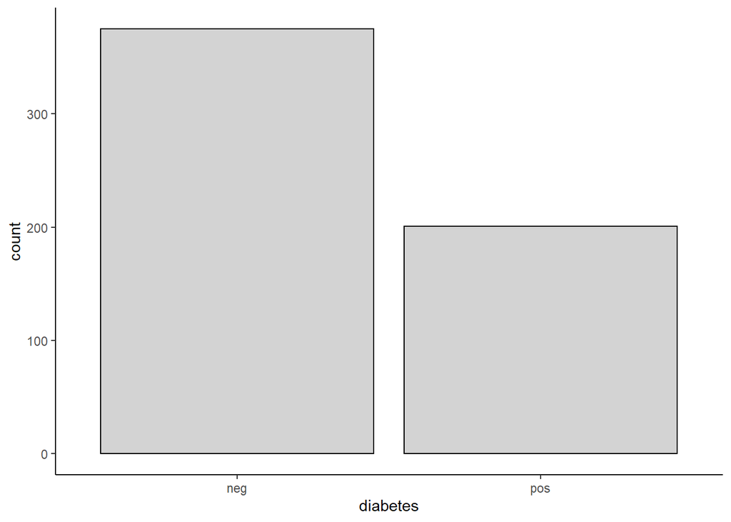

```r
feat_trn %>%
  ggplot(aes(x = diabetes)) +
  geom_bar(fill = "light grey", color = "black") +
  theme_classic()
```

Once you have your final recipe you will also want to make a feature matrix from test set. **Do not perfom any EDA on this feature matrix though!** This feature matrix ideally should be used only once for evaluating your model.

```r
feat_test <- rec %>%
  prep(training = data_trn, strings_as_factors = FALSE) %>%
  bake(new_data = data_test) # bake on test data
```

### Model Selection

Set up a tracking tibble to keep track of model performance

```r
track_accuracy <- tibble(model = character(),
                         accuracy_trn = numeric(),
                         n_features = numeric())
```

#### 1. No regularization

Fit model

```r
fit_lr <-
  logistic_reg() %>%
  set_engine("glm") %>%
  fit(diabetes ~ ., data = feat_trn)
```

estimated model performance

```r
lr_train <- accuracy_vec(feat_trn$diabetes, predict(fit_lr, feat_trn, type = "class")$.pred_class)
```

n features

```r
lr_feat <- fit_lr %>%
  tidy() %>%
  filter(estimate != 0 & term != "(Intercept)") %>%
  nrow()

# note: to see model coefficients use this code
fit_lr %>%
  tidy()
```

```
## # A tibble: 15 x 5
##    term                                 estimate std.error statistic  p.value
##    <chr>                                   <dbl>     <dbl>     <dbl>    <dbl>
##  1 (Intercept)                           -1.02       4.21    -0.241  8.09e- 1
##  2 n_pregnancies                          0.563      0.148    3.80   1.42e- 4
##  3 glucose                                1.13       0.138    8.19   2.66e-16
##  4 pressure                              -0.0762     0.127   -0.600  5.48e- 1
##  5 triceps                               -0.0486     0.133   -0.365  7.15e- 1
##  6 insulin                               -0.167      0.131   -1.28   2.01e- 1
##  7 bmi                                    0.419      0.202    2.07   3.84e- 2
##  8 pedigree                               0.366      0.120    3.06   2.23e- 3
##  9 age                                    0.0756     0.134    0.565  5.72e- 1
## 10 pregnant_history_Never.been.pregnant   0.229      0.129    1.77   7.74e- 2
## 11 insulin_rating_Moderately.high         0.0633     0.139    0.456  6.48e- 1
## 12 insulin_rating_Very.high               0.297      0.177    1.67   9.42e- 2
## 13 weight_Obese                           0.800      0.332    2.41   1.60e- 2
## 14 weight_Overweight                      0.574      0.268    2.15   3.19e- 2
## 15 weight_Underweight                    -0.798     58.2     -0.0137 9.89e- 1
```

add to tracking tibble

```r
track_accuracy <- add_row(track_accuracy,
                          model = "LR w/no regularization",
                          accuracy_trn = lr_train,
                          n_features = lr_feat)

track_accuracy
```

```
## # A tibble: 1 x 3
##   model                  accuracy_trn n_features
##   <chr>                         <dbl>      <dbl>
## 1 LR w/no regularization        0.785         14
```

#### 2. Lasso regularization

Hyperparameter = An L1 norm penalty (λ)

With regularization we will need to use resampling to tune our hyperparameter

```r
splits_boot <- data_trn %>%
  bootstraps(times = 100, strata = "diabetes")
```

Set tune grid

```r
grid_penalty <- expand_grid(penalty = exp(seq(-7, 3, length.out = 200)))
```

Fit models

```r
fits_lasso <- logistic_reg(penalty = tune(),
                           mixture = 1) %>%
  set_engine("glmnet") %>%
  set_mode("classification") %>%
  tune_grid(preprocessor = rec,
            resamples = splits_boot,
            grid = grid_penalty,
            metrics = metric_set(accuracy))
```

Check hyperparameters

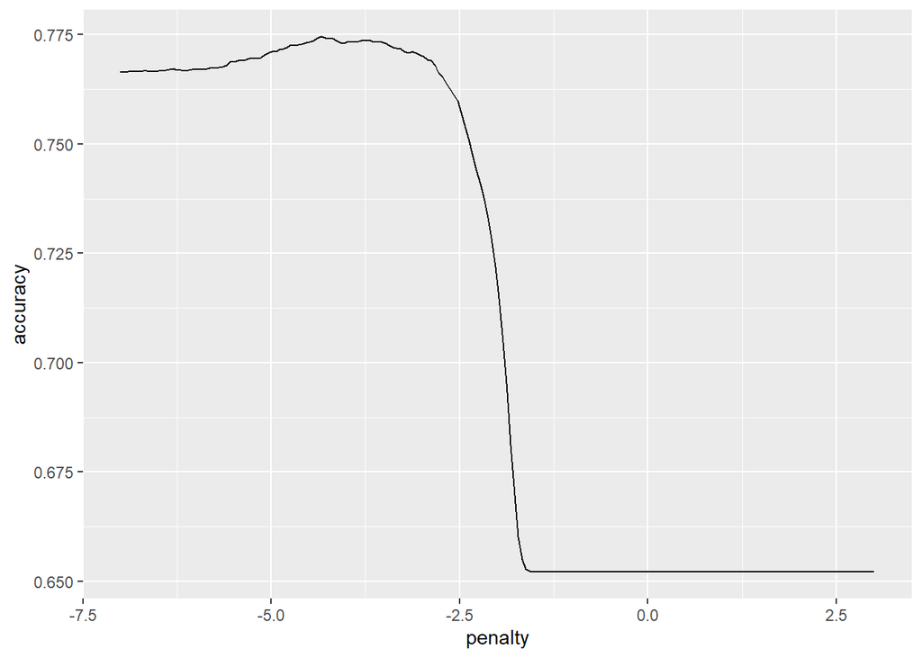

```r
plot_hyperparameters(fits_lasso, hp1 = "penalty", metric = "accuracy", log_hp1 = TRUE)
```

Best penalty value

```r
show_best(fits_lasso)
```

```
## # A tibble: 5 x 7
##   penalty .metric  .estimator  mean     n std_err .config
##     <dbl> <chr>    <chr>      <dbl> <int>   <dbl> <chr>
## 1  0.0131 accuracy binary     0.775   100 0.00262 Preprocessor1_Model054
## 2  0.0138 accuracy binary     0.774   100 0.00261 Preprocessor1_Model055
## 3  0.0124 accuracy binary     0.774   100 0.00257 Preprocessor1_Model053
## 4  0.0145 accuracy binary     0.774   100 0.00258 Preprocessor1_Model056
## 5  0.0152 accuracy binary     0.774   100 0.00262 Preprocessor1_Model057
```

estimated model performance  
**Question: Why do we first need to train the model again before getting performance and coefficient estimates?**

```r
fit_lasso <- logistic_reg(penalty = select_best(fits_lasso)$penalty,
                        mixture = 1) %>%
  set_engine("glmnet") %>%
  set_mode("classification") %>%
  fit(diabetes ~ ., data = feat_trn)


lasso_train <- accuracy_vec(feat_trn$diabetes, predict(fit_lasso, feat_trn, type = "class")$.pred_class)
```

n features

```r
# Coefficients have now been zeroed out of the model
fit_lasso %>%
  tidy()
```

```
## # A tibble: 15 x 3
##    term                                 estimate penalty
##    <chr>                                   <dbl>   <dbl>
##  1 (Intercept)                           -0.825   0.0131
##  2 n_pregnancies                          0.421   0.0131
##  3 glucose                                1.00    0.0131
##  4 pressure                               0       0.0131
##  5 triceps                                0       0.0131
##  6 insulin                                0       0.0131
##  7 bmi                                    0.417   0.0131
##  8 pedigree                               0.235   0.0131
##  9 age                                    0.0237  0.0131
## 10 pregnant_history_Never.been.pregnant   0.0702  0.0131
## 11 insulin_rating_Moderately.high         0       0.0131
## 12 insulin_rating_Very.high               0.0861  0.0131
## 13 weight_Obese                           0.150   0.0131
## 14 weight_Overweight                      0       0.0131
## 15 weight_Underweight                     0       0.0131
```

```r
lasso_feat <- fit_lasso %>%
  tidy() %>%
  filter(estimate != 0 & term != "(Intercept)") %>%
  nrow()
```

add to tracking tibble

```r
track_accuracy <- add_row(track_accuracy,
                          model = "Lasso regularization",
                          accuracy_trn = lasso_train,
                          n_features = lasso_feat)

track_accuracy
```

```
## # A tibble: 2 x 3
##   model                  accuracy_trn n_features
##   <chr>                         <dbl>      <dbl>
## 1 LR w/no regularization        0.785         14
## 2 Lasso regularization          0.778          8
```

Lets see how these 2 models compare in new data  
*Note: this is only for educational purposes, you would not want to do anything with your test set yet*

```r
lr_test <- accuracy_vec(feat_test$diabetes, predict(fit_lr, feat_test, type = "class")$.pred_class)
lasso_test <- accuracy_vec(feat_test$diabetes, predict(fit_lasso, feat_test, type = "class")$.pred_class)

track_accuracy %>%
  mutate(accuracy_test = c(lr_test, lasso_test)) %>%
  select(1:2, 4, 3)
```

```
## # A tibble: 2 x 4
##   model                  accuracy_trn accuracy_test n_features
##   <chr>                         <dbl>         <dbl>      <dbl>
## 1 LR w/no regularization        0.785         0.766         14
## 2 Lasso regularization          0.778         0.766          8
```

#### 3. Ridge regularization

Hyperparameter = An L2 norm penalty (λ)

We can use same bootstrap splits for our ridge and elasticnet models

Set tune grid

```r
grid_penalty <- expand_grid(penalty = exp(seq(-6, 4, length.out = 200)))
```

Fit models

```r
fits_ridge <- logistic_reg(penalty = tune(),
                           mixture = 0) %>%
  set_engine("glmnet") %>%
  set_mode("classification") %>%
  tune_grid(preprocessor = rec,
            resamples = splits_boot,
            grid = grid_penalty,
            metrics = metric_set(accuracy))
```

Check hyperparameters

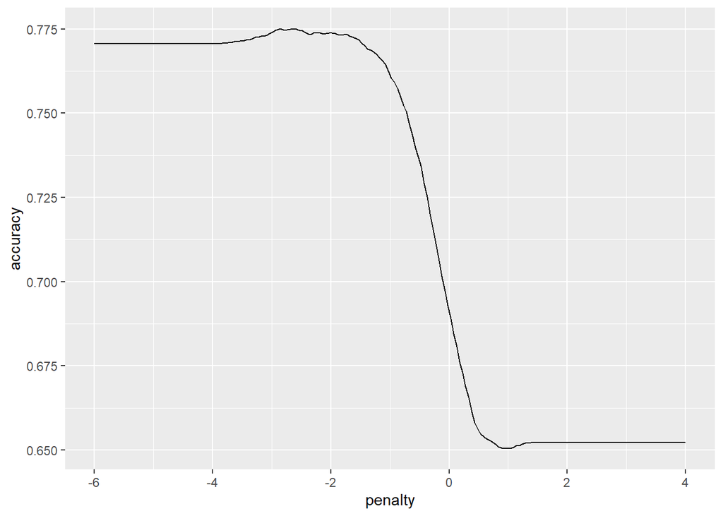

```r
plot_hyperparameters(fits_ridge, hp1 = "penalty", metric = "accuracy", log_hp1 = TRUE)
```

Best penalty value

```r
show_best(fits_ridge)
```

```
## # A tibble: 5 x 7
##   penalty .metric  .estimator  mean     n std_err .config
##     <dbl> <chr>    <chr>      <dbl> <int>   <dbl> <chr>
## 1  0.0719 accuracy binary     0.775   100 0.00260 Preprocessor1_Model068
## 2  0.0756 accuracy binary     0.775   100 0.00261 Preprocessor1_Model069
## 3  0.0588 accuracy binary     0.775   100 0.00259 Preprocessor1_Model064
## 4  0.0559 accuracy binary     0.775   100 0.00258 Preprocessor1_Model063
## 5  0.0683 accuracy binary     0.775   100 0.00263 Preprocessor1_Model067
```

estimated model performance

```r
fit_ridge <- logistic_reg(penalty = select_best(fits_ridge)$penalty,
                        mixture = 0) %>%
  set_engine("glmnet") %>%
  set_mode("classification") %>%
  fit(diabetes ~ ., data = feat_trn)


ridge_train <- accuracy_vec(feat_trn$diabetes, predict(fit_ridge, feat_trn, type = "class")$.pred_class)
```

n features

```r
ridge_feat <- fit_ridge %>%
  tidy() %>%
  filter(estimate != 0 & term != "(Intercept)") %>%
  nrow()
```

add to tracking tibble

```r
track_accuracy <- add_row(track_accuracy,
                          model = "Ridge regularization",
                          accuracy_trn = ridge_train,
                          n_features = ridge_feat)

track_accuracy
```

```
## # A tibble: 3 x 3
##   model                  accuracy_trn n_features
##   <chr>                         <dbl>      <dbl>
## 1 LR w/no regularization        0.785         14
## 2 Lasso regularization          0.778          8
## 3 Ridge regularization          0.790         14
```

#### 4. Elasticnet regularization

This model has two hyper-parameters:

λ controls the degree of regularization as before α is a “mixing” parameter that blends the degree of L1 and L2 contributions to the aggregate penalty. (Proportion of LASSO penalty)  
α = 1 results in the LASSO model  
α = 0 results in the Ridge model  
Intermediate values for α blend these penalties together proportionally to include more or less LASSO penalty

Set tune grid

```r
grid_penalty <- expand_grid(penalty = exp(seq(-6, 3, length.out = 200)),
                            mixture = seq(0, 1, length.out = 11))
```

Fit models

```r
fits_en <- logistic_reg(penalty = tune(),
                        mixture = tune()) %>%
  set_engine("glmnet") %>%
  set_mode("classification") %>%
  tune_grid(preprocessor = rec,
            resamples = splits_boot,
            grid = grid_penalty,
            metrics = metric_set(accuracy))
```

Check hyperparameters

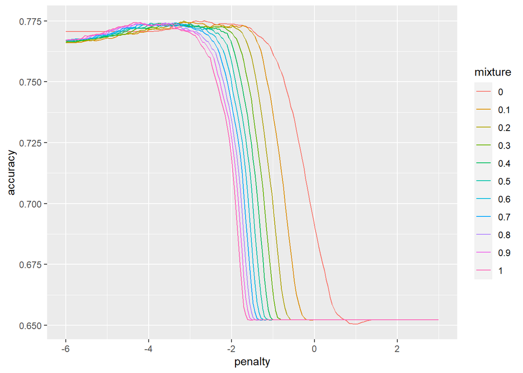

```r
plot_hyperparameters(fits_en, hp1 = "penalty", hp2 = "mixture", metric = "accuracy", log_hp1 = TRUE)
```

Best penalty value

```r
show_best(fits_en)
```

```
## # A tibble: 5 x 8
##   penalty mixture .metric  .estimator  mean     n std_err .config
##     <dbl>   <dbl> <chr>    <chr>      <dbl> <int>   <dbl> <chr>
## 1  0.0704     0   accuracy binary     0.775   100 0.00259 Preprocessor1_Model00~
## 2  0.0562     0   accuracy binary     0.775   100 0.00257 Preprocessor1_Model00~
## 3  0.0428     0.2 accuracy binary     0.775   100 0.00262 Preprocessor1_Model04~
## 4  0.0588     0   accuracy binary     0.775   100 0.00259 Preprocessor1_Model00~
## 5  0.0737     0   accuracy binary     0.775   100 0.00261 Preprocessor1_Model00~
```

estimated model performance

```r
fit_en <- logistic_reg(penalty = select_best(fits_en)$penalty,
                       mixture = 0) %>%
  set_engine("glmnet") %>%
  set_mode("classification") %>%
  fit(diabetes ~ ., data = feat_trn)


en_train <- accuracy_vec(feat_trn$diabetes, predict(fit_en, feat_trn, type = "class")$.pred_class)
```

n features

```r
en_feat <- fit_en %>%
  tidy() %>%
  filter(estimate != 0 & term != "(Intercept)") %>%
  nrow()
```

add to tracking tibble

```r
track_accuracy <- add_row(track_accuracy,
                          model = "Elasticnet regularization",
                          accuracy_trn = en_train,
                          n_features = en_feat)

track_accuracy
```

```
## # A tibble: 4 x 3
##   model                     accuracy_trn n_features
##   <chr>                            <dbl>      <dbl>
## 1 LR w/no regularization           0.785         14
## 2 Lasso regularization             0.778          8
## 3 Ridge regularization             0.790         14
## 4 Elasticnet regularization        0.790         14
```

**Question: Which model should we select?**

### Model evaluation

Note we are not selecting and evaluating our model on the same data to avoid optimization bias. Optimization bias results in slightly overestimating how well a model will perform on new data. This may be okay depending on your research question.

```r
# refit best model on entire data set
fit_best <- fit_en

accuracy_vec(feat_test$diabetes, predict(fit_best, feat_test)$.pred_class)
```

```
## [1] 0.75
```

Get final model coefficients on full data set

```r
fit_best %>%
  tidy()
```

[output not shown]

Feature important indices

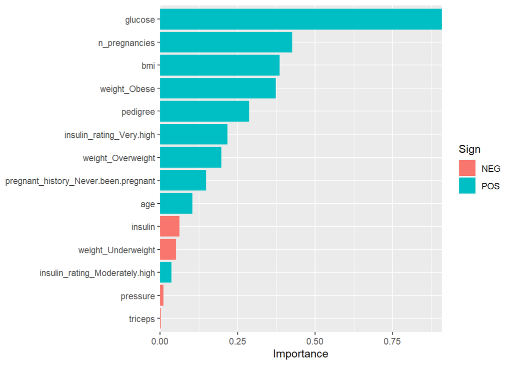

```r
fit_best$fit %>%
  vip::vi() %>%
  mutate(
    Importance = abs(Importance),
    Variable = fct_reorder(Variable, Importance)
  ) %>%
  ggplot(aes(x = Importance, y = Variable, fill = Sign)) +
  geom_col() +
  scale_x_continuous(expand = c(0, 0)) +
  labs(y = NULL)
```